# Random Forest Fitting and Evaluation

Doug Antibus

2023-12-28

### Model fitting and evaluation

After tuning several candidate random forest models using cross-validation with the training dataset, we identified a putative best combination of parameters for model fitting. The next step is to fit a model on the the complete training dataset using these parameters and evaluate fit on the test dataset.

Read in the train and test data. Note that the test data were not used in random forest tuning, so these represent truly “unseen” data.

```r
train <- read_csv(here("data", "train.csv"))
test <- read_csv(here("data", "test.csv"))
```

As with model tuning, we’ll lump infrequent start and end stations together, but this time using a minimum frequency of 500. Additionally, we’ll find the intersect of `start_name` and `end_name` in the train and test datasets, and limit records to those having start and end names in the intersect.

```r
train <- train %>% mutate(start_name = fct_lump_min(start_name, 500),
                 end_name = fct_lump_min(end_name, 500))

test <- test %>% mutate(start_name = fct_lump_min(start_name, 500),
                          end_name = fct_lump_min(end_name, 500))
```

Filtering on the name intersects slightly decreases the number of records in the training datset and does not change the number of records in the test dataset.

```r
# find start and end intersects
sn <- intersect(unique(train$start_name), unique(test$start_name)) %>% sort()
en <- intersect(unique(train$end_name), unique(test$end_name)) %>% sort()

# filter on intersects
train <- train %>%  filter(start_name %in% sn, end_name %in% en)
test <- test %>%  filter(start_name %in% sn, end_name %in% en)
```

```
## # A tibble: 4 × 3
##   dataset intersect records
##   <chr>   <chr>       <int>
## 1 train   before    2996630
## 2 train   after     2887135
## 3 test    before    1284270
## 4 test    after     1284270
```

This leaves us with ~ 430 unique start and end stations, which is similar to the number of unique stations we had for model tuning.

```
## # A tibble: 4 × 3
##   data  type  unique_values
##   <chr> <chr>         <int>
## 1 train start           432
## 2 train end             435
## 3 test  start           432
## 4 test  end             435
```

Create the recipe, model specification, and workflow.

```r
recipe <- recipe(member_casual ~ ride_id + rideable_type + hod + dow + month + start_name
                 + end_name + is_weekend + is_holiday + round_trip, data = train) %>%
          update_role(ride_id, new_role = "id variable")

rf_model <- rand_forest(
 mode = "classification",
 trees = 500,
 mtry = 5,
 min_n = 40) %>%
 set_engine("ranger", num.threads = 12, importance = "impurity")

rf_wf <- workflow() %>%
  add_model(rf_model) %>%
  add_recipe(recipe)
```

Next we fit the model on the complete training dataset and predict for both the test and train data using `broom::augment`.

```r
tictoc::tic()
fit <- rf_wf %>% fit(train)
tictoc::toc()

test_augmented <- fit %>% broom::augment(test) %>%
  mutate(member = factor(ifelse(member_casual == "casual", 1, 0)))

train_augmented <- fit %>% broom::augment(train) %>%
  mutate(member = factor(ifelse(member_casual == "casual", 1, 0)))
```

We calculate accuracy and ROC AUC for both the training and test predictions, and put these into a table.

```r
train_auc <- roc_auc(train_augmented, member, .pred_member) %>% pull(.estimate)
test_auc <- roc_auc(test_augmented, member, .pred_member)  %>% pull(.estimate)

test_accuracy <- test_augmented %>%
  mutate(.pred_mem = factor(ifelse(.pred_class == "casual", 1, 0))) %>%
  accuracy(member, .pred_mem) %>% pull(.estimate)

train_accuracy <- train_augmented %>%
  mutate(.pred_mem = factor(ifelse(.pred_class == "casual", 1, 0))) %>%
  accuracy(member, .pred_mem) %>% pull(.estimate)

metrics_table <- tibble(
  data = rep(c("train", "test"), each = 2),
  metric = rep(c("accuracy", "AUC"), 2),
  value = c(train_accuracy, train_auc, test_accuracy, test_auc)
  )

metrics_table %>% write_csv(here("results", "metrics_table_5_40.csv"))
```

The model seems to have been overfit somewhat on the training data, since training accuracy and ROC AUC are both higher than the corresponding test metrics. However test AUC is still ~ 0.75, which shows that our model has decent predictive value.

```r
met_table <- read_csv(here("results", "metrics_table_5_40.csv"))
met_table
```

```
## # A tibble: 4 × 3
##   data  metric   value
##   <chr> <chr>    <dbl>
## 1 train accuracy 0.793
## 2 train AUC      0.892
## 3 test  accuracy 0.715
## 4 test  AUC      0.748
```

Plotting the training and testing ROC curves, we see that the train ROC curve looks markedly better than the test ROC curve, although the test curve is clearly more predictive than the slope = 1 baseline.

**Training** ROC curve

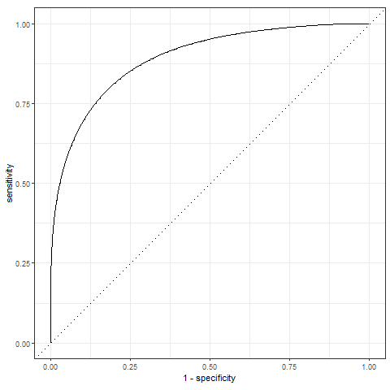

```r
knitr::include_graphics(here("images", "train_roc_curve.png"), dpi = 100)
```

**Testing** ROC curve

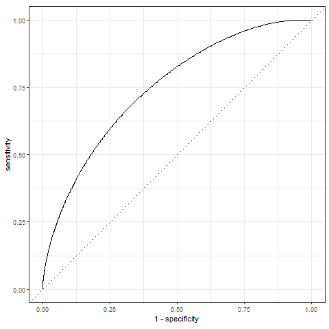

```r
knitr::include_graphics(here("images", "test_roc_curve.png"), dpi = 100)
```

Finally, we examine variable importance, which indicates that start and end stations are the most important variables. We didn’t do a detailed examination of start and end stations during EDA, but we will examine these with maps next.

Other important variables match findings from EDA. For example, we found that members and casual users displayed different patterns of hourly (`hod`) trip start times. We also saw that members and casual users differed in the `rideable_type` of bikes used, and casual users tended to take more trips on weekends during late-spring and summer months.

These findings from the model add credibility to what we discovered during EDA and will provide guidance for **Cyclistic** in developing marketing strategies aimed at converting casual users into membership holders.

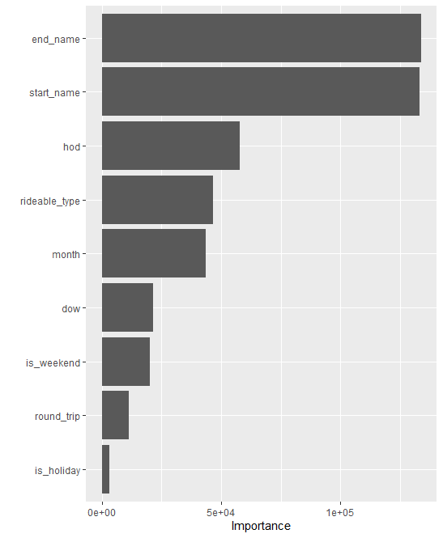

```r
knitr::include_graphics(here("images", "model_vip.png"), dpi = 100)
```